# 二手车价格预测

```python
import warnings
warnings.filterwarnings('ignore')

import pandas as pd
import numpy as np
import matplotlib.pyplot as plt
import seaborn as sns

from sklearn.preprocessing import LabelEncoder
from sklearn.preprocessing import OneHotEncoder
from scipy.stats import entropy

import xgboost as xgb
from xgboost import plot_importance
from xgboost.sklearn import XGBRegressor
from sklearn.model_selection import train_test_split,KFold,GridSearchCV
from sklearn.metrics import mean_absolute_error

from pylab import mpl
mpl.rcParams['font.sans-serif'] = ['SimHei']
mpl.rcParams['axes.unicode_minus'] = False

%matplotlib inline
```

## 一、EDA

#### 数据总体情况

```python
data_train = pd.read_csv('D:/数据分析/二手车价格预测/used_car_train_20200313.csv',delimiter=' ')
data_test = pd.read_csv('D:/数据分析/二手车价格预测/used_car_testA_20200313.csv',delimiter=' ')
```

```python
data_train.head(3).append(data_train.tail(3))
```

|  | SaleID | name | regDate | model | brand | bodyType | fuelType | gearbox | power | kilometer | ... | v_5 | v_6 | v_7 | v_8 | v_9 | v_10 | v_11 | v_12 | v_13 | v_14 |
| --- | --- | --- | --- | --- | --- | --- | --- | --- | --- | --- | --- | --- | --- | --- | --- | --- | --- | --- | --- | --- | --- |
| 0 | 0 | 736 | 20040402 | 30.0 | 6 | 1.0 | 0.0 | 0.0 | 60 | 12.5 | ... | 0.235676 | 0.101988 | 0.129549 | 0.022816 | 0.097462 | -2.881803 | 2.804097 | -2.420821 | 0.795292 | 0.914762 |
| 1 | 1 | 2262 | 20030301 | 40.0 | 1 | 2.0 | 0.0 | 0.0 | 0 | 15.0 | ... | 0.264777 | 0.121004 | 0.135731 | 0.026597 | 0.020582 | -4.900482 | 2.096338 | -1.030483 | -1.722674 | 0.245522 |
| 2 | 2 | 14874 | 20040403 | 115.0 | 15 | 1.0 | 0.0 | 0.0 | 163 | 12.5 | ... | 0.251410 | 0.114912 | 0.165147 | 0.062173 | 0.027075 | -4.846749 | 1.803559 | 1.565330 | -0.832687 | -0.229963 |
| 149997 | 149997 | 147587 | 20101003 | 60.0 | 11 | 1.0 | 1.0 | 0.0 | 90 | 6.0 | ... | 0.233353 | 0.000705 | 0.118872 | 0.100118 | 0.097914 | 2.439812 | -1.630677 | 2.290197 | 1.891922 | 0.414931 |
| 149998 | 149998 | 45907 | 20060312 | 34.0 | 10 | 3.0 | 1.0 | 0.0 | 156 | 15.0 | ... | 0.256369 | 0.000252 | 0.081479 | 0.083558 | 0.081498 | 2.075380 | -2.633719 | 1.414937 | 0.431981 | -1.659014 |
| 149999 | 149999 | 177672 | 19990204 | 19.0 | 28 | 6.0 | 0.0 | 1.0 | 193 | 12.5 | ... | 0.284475 | 0.000000 | 0.040072 | 0.062543 | 0.025819 | 1.978453 | -3.179913 | 0.031724 | -1.483350 | -0.342674 |

6 rows × 31 columns

```python
print("train's shape:",data_train.shape)
print("test's shape:",data_test.shape)
```

```
train's shape: (150000, 31)
test's shape: (50000, 30)
```

```python
data_train.info()
```

```
<class 'pandas.core.frame.DataFrame'>
RangeIndex: 150000 entries, 0 to 149999
Data columns (total 31 columns):
 #   Column             Non-Null Count   Dtype
---  ------             --------------   -----
 0   SaleID             150000 non-null  int64
 1   name               150000 non-null  int64
 2   regDate            150000 non-null  int64
 3   model              149999 non-null  float64
 4   brand              150000 non-null  int64
 5   bodyType           145494 non-null  float64
 6   fuelType           141320 non-null  float64
 7   gearbox            144019 non-null  float64
 8   power              150000 non-null  int64
 9   kilometer          150000 non-null  float64
```

[output cut: 23 more lines]

- SaleID 交易ID，唯一编码
- name 汽车交易名称，已脱敏
- regDate 汽车注册日期
- model 车型编码，已脱敏
- brand 汽车品牌，已脱毛
- bodyType 车身类型 豪华轿车：0，微型车：1，厢型车：2，大巴车：3，敞篷车：4，双门汽车：5，商务车：6，搅拌车：7
- fuelType 燃油类型 汽油：0，柴油：1，液化石油气：2，天然气：3，混合动力：4，其他：5，电动：6
- gearbox 变速箱 手动：0，自动：1
- power 发动机功率 范围 [0,600]
- kilometer 汽车已行驶公里，单位万km
- noteRepaireDamage 汽车有尚未修复的损坏 是：0，否：1
- regionCode 地区编码，已脱敏
- seller 销售方 个体：0，非个体：1
- offerType 报价类型 提供：0，请求：1
- creatDate 汽车上线时间，即开始售卖时间
- price 二手车交易价格（预测目标）
- v系列特征 匿名特征，共15个

```python
# train的缺失值
null_fea = data_train.isnull().sum()
null_fea = null_fea[null_fea != 0]
null_fea = pd.DataFrame({'columns':null_fea.index, 'num':null_fea.values, 'proportion%':null_fea.values/len(data_train)*100})
null_fea
```

|  | columns | num | proportion% |
| --- | --- | --- | --- |
| 0 | model | 1 | 0.000667 |
| 1 | bodyType | 4506 | 3.004000 |
| 2 | fuelType | 8680 | 5.786667 |
| 3 | gearbox | 5981 | 3.987333 |

```python
# test的缺失值
null_fea1 = data_test.isnull().sum()
null_fea1 = null_fea1[null_fea1 != 0]
null_fea1 = pd.DataFrame({'columns':null_fea1.index, 'num':null_fea1.values, 'proportion%':null_fea1.values/len(data_test)*100})
null_fea1
```

|  | columns | num | proportion% |
| --- | --- | --- | --- |
| 0 | bodyType | 1413 | 2.826 |
| 1 | fuelType | 2893 | 5.786 |
| 2 | gearbox | 1910 | 3.820 |

```python
# 用众数填充缺失的一个model值
data_train['model'] = data_train['model'].fillna(data_train['model'].mode()[0])
data_train['model'].isnull().sum()
```

```
0
```

```python
# 重复样本
print('train:',len(data_train[data_train.duplicated(keep=False)]))
print('test:',len(data_test[data_test.duplicated(keep=False)]))
```

```
train: 0
test: 0
```

```python
# 统计量
data_train.describe()
```

|  | SaleID | name | regDate | model | brand | bodyType | fuelType | gearbox | power | kilometer | ... | v_5 | v_6 | v_7 | v_8 | v_9 | v_10 | v_11 | v_12 | v_13 | v_14 |
| --- | --- | --- | --- | --- | --- | --- | --- | --- | --- | --- | --- | --- | --- | --- | --- | --- | --- | --- | --- | --- | --- |
| count | 150000.000000 | 150000.000000 | 1.500000e+05 | 150000.000000 | 150000.000000 | 145494.000000 | 141320.000000 | 144019.000000 | 150000.000000 | 150000.000000 | ... | 150000.000000 | 150000.000000 | 150000.000000 | 150000.000000 | 150000.000000 | 150000.000000 | 150000.000000 | 150000.000000 | 150000.000000 | 150000.000000 |
| mean | 74999.500000 | 68349.172873 | 2.003417e+07 | 47.128707 | 8.052733 | 1.792369 | 0.375842 | 0.224943 | 119.316547 | 12.597160 | ... | 0.248204 | 0.044923 | 0.124692 | 0.058144 | 0.061996 | -0.001000 | 0.009035 | 0.004813 | 0.000313 | -0.000688 |
| std | 43301.414527 | 61103.875095 | 5.364988e+04 | 49.536024 | 7.864956 | 1.760640 | 0.548677 | 0.417546 | 177.168419 | 3.919576 | ... | 0.045804 | 0.051743 | 0.201410 | 0.029186 | 0.035692 | 3.772386 | 3.286071 | 2.517478 | 1.288988 | 1.038685 |
| min | 0.000000 | 0.000000 | 1.991000e+07 | 0.000000 | 0.000000 | 0.000000 | 0.000000 | 0.000000 | 0.000000 | 0.500000 | ... | 0.000000 | 0.000000 | 0.000000 | 0.000000 | 0.000000 | -9.168192 | -5.558207 | -9.639552 | -4.153899 | -6.546556 |
| 25% | 37499.750000 | 11156.000000 | 1.999091e+07 | 10.000000 | 1.000000 | 0.000000 | 0.000000 | 0.000000 | 75.000000 | 12.500000 | ... | 0.243615 | 0.000038 | 0.062474 | 0.035334 | 0.033930 | -3.722303 | -1.951543 | -1.871846 | -1.057789 | -0.437034 |
| 50% | 74999.500000 | 51638.000000 | 2.003091e+07 | 30.000000 | 6.000000 | 1.000000 | 0.000000 | 0.000000 | 110.000000 | 15.000000 | ... | 0.257798 | 0.000812 | 0.095866 | 0.057014 | 0.058484 | 1.624076 | -0.358053 | -0.130753 | -0.036245 | 0.141246 |
| 75% | 112499.250000 | 118841.250000 | 2.007111e+07 | 66.000000 | 13.000000 | 3.000000 | 1.000000 | 0.000000 | 150.000000 | 15.000000 | ... | 0.265297 | 0.102009 | 0.125243 | 0.079382 | 0.087491 | 2.844357 | 1.255022 | 1.776933 | 0.942813 | 0.680378 |
| max | 149999.000000 | 196812.000000 | 2.015121e+07 | 247.000000 | 39.000000 | 7.000000 | 6.000000 | 1.000000 | 19312.000000 | 15.000000 | ... | 0.291838 | 0.151420 | 1.404936 | 0.160791 | 0.222787 | 12.357011 | 18.819042 | 13.847792 | 11.147669 | 8.658418 |

8 rows × 30 columns

训练集和测试集存在缺失值的特征：

- bodyType
- fuelType
- gearbox

占比约3%-6%

#### 非数字类型特征的数值处理

```python
ob_fea = list(data_train.select_dtypes(include=['object']).columns)
ob_fea1 = list(data_test.select_dtypes(include=['object']).columns)
print(ob_fea,ob_fea1)
```

```
['notRepairedDamage'] ['notRepairedDamage']
```

```python
set(data_train['notRepairedDamage'])
```

```
{'-', '0.0', '1.0'}
```

```python
data_train['notRepairedDamage'] = data_train['notRepairedDamage'].map({'-':-1,'0.0':0,'1.0':1})
data_test['notRepairedDamage'] = data_test['notRepairedDamage'].map({'-':-1,'0.0':0,'1.0':1})
```

#### 将特征分为时间特征、数值特征、类别特征

```python
data_train.nunique().sort_values()
```

```
offerType                 1
seller                    2
gearbox                   2
notRepairedDamage         3
fuelType                  7
bodyType                  8
kilometer                13
brand                    40
creatDate                96
model                   248
power                   566
price                  3763
regDate                3894
regionCode             7905
name                  99662
v_6                  109766
v_7                  138709
v_5                  139624
v_9                  140617
v_8                  142451
v_12                 143997
v_0                  143997
v_11                 143997
v_2                  143997
v_10                 143997
v_14                 143998
v_3                  143998
v_1                  143998
v_13                 143998
v_4                  143998
SaleID               150000
dtype: int64
```

```python
# 数值特征
numeric_fea = ['power','kilometer'] + [col for col in data_test.columns if col.startswith('v')]

# 时间特征
date_fea = ['creatDate','regDate']

# 类别特征
categoric_fea = [col for col in data_test.columns if col not in numeric_fea+date_fea ]
categoric_fea.remove('SaleID')
```

#### 目标特征分析

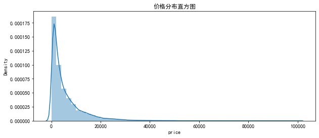

```python
f,ax = plt.subplots(figsize=(10,4))
sns.distplot(data_train['price']);
ax.set_title('价格分布直方图');
```

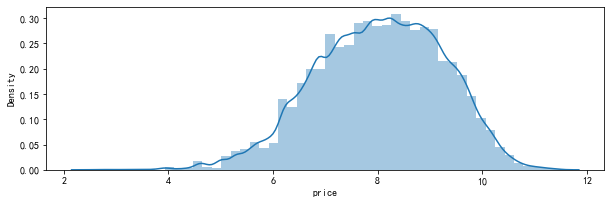

```python
# 右偏，对其做log(x+1)变换
f,ax = plt.subplots(figsize=(10,3))
sns.distplot(np.log1p(data_train['price']));
```

目标特征右偏，做对数转换后近似正态分布

#### 类别特征处理

```python
# train的类别特征情况
for col in categoric_fea:
    print(col,'的类别个数：',data_train[col].nunique(),'\n')
```

```
name 的类别个数： 99662

model 的类别个数： 248

brand 的类别个数： 40

bodyType 的类别个数： 8

fuelType 的类别个数： 7

gearbox 的类别个数： 2

notRepairedDamage 的类别个数： 3

regionCode 的类别个数： 7905

seller 的类别个数： 2

offerType 的类别个数： 1
```

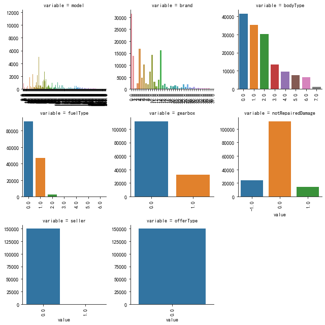

```python
# train的类别特征情况
# 仅展示类别数较少的特征

def count_plot(x,  **kwargs):
    sns.countplot(x=x)
    x=plt.xticks(rotation=90)

value_vars = [col for col in categoric_fea if col not in ['name','regionCode']]

f = pd.melt(data_train,  value_vars=value_vars)
g = sns.FacetGrid(f, col="variable",  col_wrap=3, sharex=False, sharey=False, size=3)
g = g.map(count_plot, "value")
```

```python
# test的类别特征情况
for col in categoric_fea:
    print(col,'的特征值：',data_test[col].nunique(),'\n')
```

```
name 的特征值： 37453

model 的特征值： 247

brand 的特征值： 40

bodyType 的特征值： 8

fuelType 的特征值： 7

gearbox 的特征值： 2

notRepairedDamage 的特征值： 3

regionCode 的特征值： 6971

seller 的特征值： 1

offerType 的特征值： 1
```

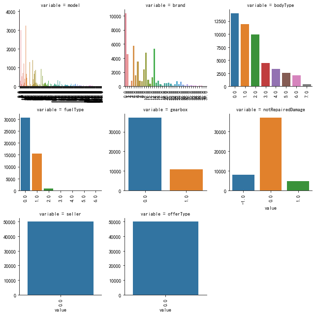

```python
# test的类别特征情况
# 仅展示类别数较少的特征

f = pd.melt(data_test,  value_vars=value_vars)
g = sns.FacetGrid(f, col="variable",  col_wrap=3, sharex=False, sharey=False, size=3)
g = g.map(count_plot, "value")
```

特征seller和offerType的类别可以删去

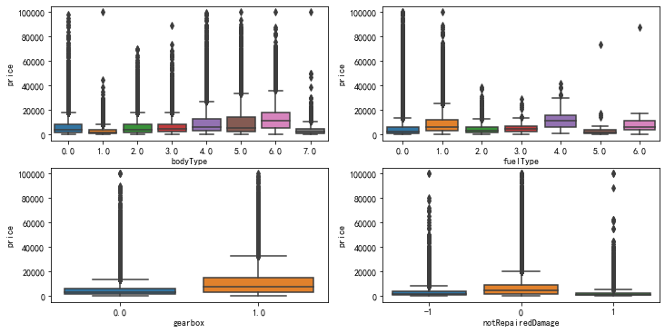

```python
# 对类别数量少的特征做箱线图

plt.figure(figsize=(12, 6))
i = 1
for col in ['bodyType', 'fuelType', 'gearbox', 'notRepairedDamage']:
    plt.subplot(2, 2, i)
    i += 1
    fig = sns.boxplot(x=data_train[col], y=data_train['price'])

plt.show()
```

上述四种特征中类别的不同会影响价格

#### 数值特征处理

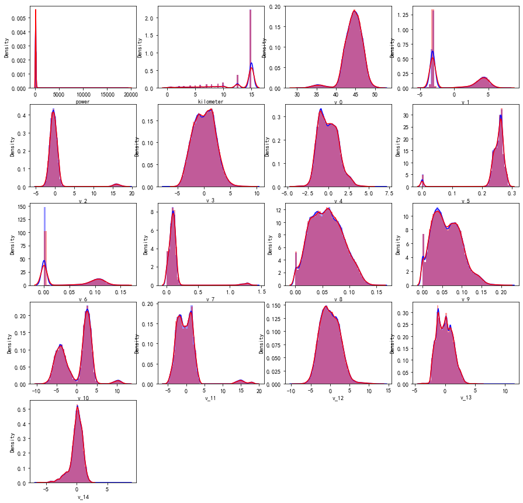

```python
# 特征分布图

plt.figure(figsize=(15,15))
i=1
for col in numeric_fea:
    plt.subplot(5,4,i)
    i += 1
    sns.distplot(data_train[col],label='train',color='b')
    sns.distplot(data_test[col], label='test', color='r')
plt.show()
```

- 训练集与测试集的分布基本一致
- power存在大于600的值，与特征定义不符
- kilometer可能已经经过分箱

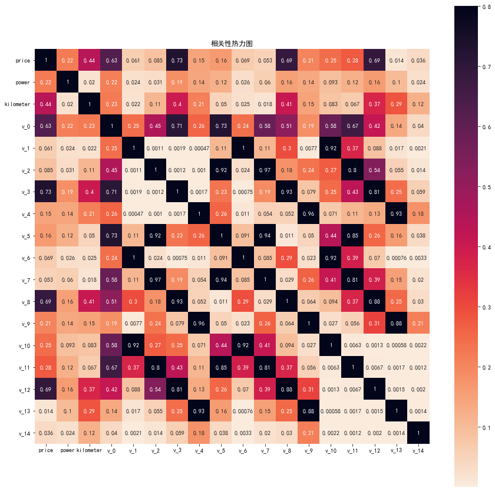

```python
# 与目标变量的相关性分析
correlation = data_train[['price']+numeric_fea].corr()

f, ax = plt.subplots(figsize=(15,15))
sns.heatmap(abs(correlation),square = True,annot=True,vmax=0.8,cmap=sns.cm.rocket_r);
ax.set_title('相关性热力图');
```

v0 v3 v8 v12 与price具有较强的线性相关性

#### 时间特征

```python
data_train[date_fea].describe()
```

|  | creatDate | regDate |
| --- | --- | --- |
| count | 1.500000e+05 | 1.500000e+05 |
| mean | 2.016033e+07 | 2.003417e+07 |
| std | 1.067328e+02 | 5.364988e+04 |
| min | 2.015062e+07 | 1.991000e+07 |
| 25% | 2.016031e+07 | 1.999091e+07 |
| 50% | 2.016032e+07 | 2.003091e+07 |
| 75% | 2.016033e+07 | 2.007111e+07 |
| max | 2.016041e+07 | 2.015121e+07 |

```python
# 训练集日检验查
print(data_train[date_fea].astype('str').applymap(lambda x:int(x[6:])).max(),'\n\n',
      data_train[date_fea].astype('str').applymap(lambda x:int(x[6:])).min(),'\n\n')

# 训练集月检查
print(data_train[date_fea].astype('str').applymap(lambda x:int(x[4:6])).max(),'\n\n',
      data_train[date_fea].astype('str').applymap(lambda x:int(x[4:6])).min())
```

```
creatDate    31
regDate      12
dtype: int64

 creatDate    1
regDate      1
dtype: int64


creatDate    12
regDate      12
dtype: int64

 creatDate    1
regDate      0
dtype: int64
```

regDate中的数据有误，存在0月

```python
# 暂时将0月份改为1月份，对0月份的样本进行标记
data_train[date_fea] = data_train[date_fea].astype('str')
data_train['regFalse'] = data_train['regDate'].map(lambda x:1 if int(x[4:6])==0 else 0)

data_train['regDate_1'] = data_train['regDate'].map(lambda x:x[:4]+'01'+x[6:] if int(x[4:6])==0 else x)

# 将regDate和creatDate分别拆分成年、月、日指标
for col in ['regDate_1','creatDate']:
    a = pd.to_datetime(data_train[col])
    data_train[col+'_year'] = a.dt.year
    data_train[col+'_month'] = a.dt.month
    data_train[col+'_day'] = a.dt.day

# 将0月份标注为-1
data_train['regDate_1_month'][data_train['regFalse']==1] = -1
```

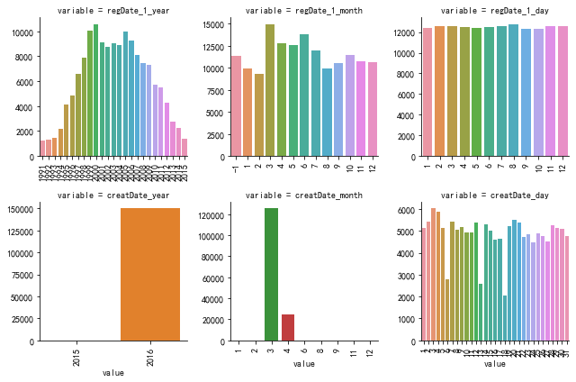

```python
f = pd.melt(data_train,value_vars=list(data_train.columns[-6:]))
g = sns.FacetGrid(f,col='variable',col_wrap=3,sharex=False,sharey=False,size=3)
g.map(count_plot,'value');
```

```python
# 测试集同上处理
data_test[date_fea] = data_test[date_fea].astype('str')
data_test['regFalse'] = data_test['regDate'].map(lambda x:1 if int(x[4:6])==0 else 0)

data_test['regDate_1'] = data_test['regDate'].map(lambda x:x[:4]+'01'+x[6:] if int(x[4:6])==0 else x)

for col in ['regDate_1','creatDate']:
    a = pd.to_datetime(data_test[col])
    data_test[col+'_year'] = a.dt.year
    data_test[col+'_month'] = a.dt.month
    data_test[col+'_day'] = a.dt.day

data_test['regDate_1_month'][data_test['regFalse']==1] = -1
```

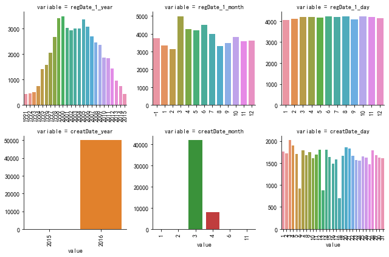

```python
f = pd.melt(data_test,value_vars=list(data_train.columns[-6:]))
g = sns.FacetGrid(f,col='variable',col_wrap=3,sharex=False,sharey=False,size=3)
g.map(count_plot,'value');
```

将时间转化为年月日指标后，训练集与测试集在这几个指标上的分布基本一致

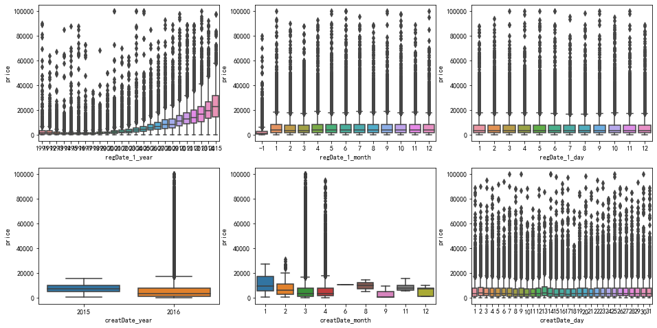

```python
i = 1

plt.figure(figsize=(16,8))
for col in list(data_train.columns[-6:]):
    plt.subplot(2,3,i)
    i +=1
    fig = sns.boxplot(x=data_train[col], y=data_train['price'])

plt.show()
```

```python
data_train['creatDate_year'].value_counts()
```

```
2016    149982
2015        18
Name: creatDate_year, dtype: int64
```

```python
data_train['creatDate_month'].value_counts()
```

```
3     125426
4      24344
2        185
1         27
11         7
12         5
9          3
8          2
6          1
Name: creatDate_month, dtype: int64
```

- 由箱线图发现，reg_year越大，价格越大，因此将reg_year加入类别特征之中
- creat_year、creat_date的变化下价格也有波动，但这两个特征的值都集中在某个类别上，波动源于某些类别下样本数过小

```python
# 将regDate_1_year加入类别特征中
data_train['reg_year'] = data_train['regDate_1_year']
data_test['reg_year'] = data_test['regDate_1_year']
categoric_fea = categoric_fea + ['reg_year']
```

```python
# 删除无用特征
data_train = data_train.drop(list(data_train.columns[-9:-1]),axis=1)
data_test = data_test.drop(list(data_test.columns[-9:-1]),axis=1)
```

```python
data_train.info()
```

```
<class 'pandas.core.frame.DataFrame'>
RangeIndex: 150000 entries, 0 to 149999
Data columns (total 32 columns):
 #   Column             Non-Null Count   Dtype
---  ------             --------------   -----
 0   SaleID             150000 non-null  int64
 1   name               150000 non-null  int64
 2   regDate            150000 non-null  object
 3   model              150000 non-null  float64
 4   brand              150000 non-null  int64
 5   bodyType           145494 non-null  float64
 6   fuelType           141320 non-null  float64
 7   gearbox            144019 non-null  float64
 8   power              150000 non-null  int64
 9   kilometer          150000 non-null  float64
```

[output cut: 24 more lines]

EDA总结：

## 二、特征工程

```python
# 合并训练集与测试集一起处理
data = pd.concat([data_train, data_test], ignore_index=True)
data.head(3).append(data.tail(3))
```

|  | SaleID | name | regDate | model | brand | bodyType | fuelType | gearbox | power | kilometer | ... | v_6 | v_7 | v_8 | v_9 | v_10 | v_11 | v_12 | v_13 | v_14 | reg_year |
| --- | --- | --- | --- | --- | --- | --- | --- | --- | --- | --- | --- | --- | --- | --- | --- | --- | --- | --- | --- | --- | --- |
| 0 | 0 | 736 | 20040402 | 30.0 | 6 | 1.0 | 0.0 | 0.0 | 60 | 12.5 | ... | 0.101988 | 0.129549 | 0.022816 | 0.097462 | -2.881803 | 2.804097 | -2.420821 | 0.795292 | 0.914762 | 2004 |
| 1 | 1 | 2262 | 20030301 | 40.0 | 1 | 2.0 | 0.0 | 0.0 | 0 | 15.0 | ... | 0.121004 | 0.135731 | 0.026597 | 0.020582 | -4.900482 | 2.096338 | -1.030483 | -1.722674 | 0.245522 | 2003 |
| 2 | 2 | 14874 | 20040403 | 115.0 | 15 | 1.0 | 0.0 | 0.0 | 163 | 12.5 | ... | 0.114912 | 0.165147 | 0.062173 | 0.027075 | -4.846749 | 1.803559 | 1.565330 | -0.832687 | -0.229963 | 2004 |
| 199997 | 199997 | 6693 | 20040412 | 49.0 | 1 | 0.0 | 1.0 | 1.0 | 224 | 15.0 | ... | 0.105724 | 0.117652 | 0.057479 | 0.015669 | -4.639065 | 0.654713 | 1.137756 | -1.390531 | 0.254420 | 2004 |
| 199998 | 199998 | 96900 | 20020008 | 27.0 | 1 | 0.0 | 0.0 | 1.0 | 334 | 15.0 | ... | 0.000490 | 0.137366 | 0.086216 | 0.051383 | 1.833504 | -2.828687 | 2.465630 | -0.911682 | -2.057353 | 2002 |
| 199999 | 199999 | 193384 | 20041109 | 166.0 | 6 | 1.0 | NaN | 1.0 | 68 | 9.0 | ... | 0.000300 | 0.103534 | 0.080625 | 0.124264 | 2.914571 | -1.135270 | 0.547628 | 2.094057 | -1.552150 | 2004 |

6 rows × 32 columns

```python
# 用-1填充缺失值
data = data.fillna(-1)
```

```python
# 删除无用特征

data = data.drop(['seller','offerType'],axis=1)

categoric_fea.remove('seller')
categoric_fea.remove('offerType')
```

```python
# 将power值限定在[0,600]
data['power'] = data['power'].map(lambda x:600 if x>600 else x)
```

```python
# 对类别数量少的类别特征进行独热编码

ohe_fea = ['bodyType', 'fuelType', 'gearbox', 'notRepairedDamage']
a = data
for col in ohe_fea:

    print(col,'特征:')
    print(set(data[col]))

    ohe = OneHotEncoder(sparse=False,categories ='auto')
    x = data[col].values.reshape(-1,1)
    ohe.fit(x)
    df = pd.DataFrame(ohe.transform(x))

    df.columns = [col+'_'+str(i+1) for i in range(len(df.columns))]
    data = pd.concat([data,df],axis=1)
```

```
bodyType 特征:
{0.0, 1.0, 2.0, 3.0, 4.0, 5.0, 6.0, 7.0, -1.0}
fuelType 特征:
{0.0, 1.0, 2.0, 3.0, 4.0, 5.0, 6.0, -1.0}
gearbox 特征:
{0.0, 1.0, -1.0}
notRepairedDamage 特征:
{0, 1, -1}
```

```python
# 构建使用时间特征
data['usetime'] = (pd.to_datetime(data['creatDate'],errors='coerce') - pd.to_datetime(data['regDate'],errors='coerce')).dt.days

# 空值由xgboost自行处理
```

```python
# 频率编码
count_fea = ['model','brand','regionCode']

for col in count_fea:
    data[col+'_count'] = data[col].map(data[col].value_counts())
```

```python
# 构建品牌销售统计量特征

data1 = data_train.groupby('brand')['price'].agg(['max','min','median','mean','std'])
cols = []
for col in data1.columns:
    cols.append('brand_price_'+col)

data1.columns = cols
data1 = data1.reset_index()
data = pd.merge(data,data1, on='brand', how='left')
data.head()
```

|  | SaleID | name | regDate | model | brand | bodyType | fuelType | gearbox | power | kilometer | ... | notRepairedDamage_3 | usetime | model_count | brand_count | regionCode_count | brand_price_max | brand_price_min | brand_price_median | brand_price_mean | brand_price_std |
| --- | --- | --- | --- | --- | --- | --- | --- | --- | --- | --- | --- | --- | --- | --- | --- | --- | --- | --- | --- | --- | --- |
| 0 | 0 | 736 | 20040402 | 30.0 | 6 | 1.0 | 0.0 | 0.0 | 60 | 12.5 | ... | 0.0 | 4385.0 | 3145 | 13719 | 47 | 59900 | 13 | 1800.0 | 3611.840266 | 4681.293524 |
| 1 | 1 | 2262 | 20030301 | 40.0 | 1 | 2.0 | 0.0 | 0.0 | 0 | 15.0 | ... | 0.0 | 4757.0 | 5911 | 18326 | 10 | 99900 | 15 | 6499.0 | 9273.311947 | 9369.631497 |
| 2 | 2 | 14874 | 20040403 | 115.0 | 15 | 1.0 | 0.0 | 0.0 | 163 | 12.5 | ... | 0.0 | 4382.0 | 1249 | 1969 | 19 | 45000 | 100 | 8500.0 | 9858.582990 | 5425.058140 |
| 3 | 3 | 71865 | 19960908 | 109.0 | 10 | 0.0 | 0.0 | 1.0 | 193 | 15.0 | ... | 0.0 | 7125.0 | 504 | 19015 | 47 | 98000 | 15 | 5400.0 | 8470.804197 | 8988.307535 |
| 4 | 4 | 111080 | 20120103 | 110.0 | 5 | 1.0 | 0.0 | 0.0 | 68 | 5.0 | ... | 0.0 | 1531.0 | 713 | 6234 | 6 | 31500 | 20 | 2300.0 | 3306.349411 | 3343.624586 |

5 rows × 62 columns

```python
# 用数值特征对类别特征做统计刻画
# 挑选了和price线性相关性最高的匿名特征

for col1 in count_fea:
    data1 = data.groupby(col1)
    for col2 in ['v_0','v_3','v_8','v_12']:
        data2 = data1[col2].agg([('{}_{}_max'.format(col1,col2),'max'),
                                 ('{}_{}_min'.format(col1,col2),'min'),
                                 ('{}_{}_median'.format(col1,col2),'median'),
                                 ('{}_{}_std'.format(col1,col2),'std'),
                                 ('{}_{}_mad'.format(col1,col2),'mad')])
        data2 = data2.reset_index()
        data = pd.merge(data,data2, on=col1, how='left')
```

```python
# 类别特征的二阶交叉
for colpair in [['model','brand'],['model','regionCode'],['brand','regionCode']]:

    # 共现次数
    data['_'.join(colpair)+'_count'] = data.groupby(colpair)['SaleID'].transform('count')


    # nunique、熵
    data1 = data.groupby(colpair[0])[colpair[1]].agg([('_'.join(colpair)+'_nunique','nunique'),
                                                      ('_'.join(colpair)+'_entropy',lambda x:entropy(x.value_counts()/x.shape[0]))]).reset_index()
    data = pd.merge(data,data1, on=colpair[0], how='left')

    data1 = data.groupby(colpair[1])[colpair[0]].agg([('{}_{}_nunique'.format(colpair[1],colpair[0]),'nunique'),
                                                      ('{}_{}_entropy'.format(colpair[1],colpair[0]),lambda x:entropy(x.value_counts()/x.shape[0]))]).reset_index()
    data = pd.merge(data,data1, on=colpair[1], how='left')
```

```python
# 数据拆分
data_train = data[data['price'] != -1]
data_test = data[data['price'] == -1]
```

```python
data_train.columns.values
```

```
array(['SaleID', 'name', 'regDate', 'model', 'brand', 'bodyType',
       'fuelType', 'gearbox', 'power', 'kilometer', 'notRepairedDamage',
       'regionCode', 'creatDate', 'price', 'v_0', 'v_1', 'v_2', 'v_3',
       'v_4', 'v_5', 'v_6', 'v_7', 'v_8', 'v_9', 'v_10', 'v_11', 'v_12',
       'v_13', 'v_14', 'reg_year', 'bodyType_1', 'bodyType_2',
       'bodyType_3', 'bodyType_4', 'bodyType_5', 'bodyType_6',
       'bodyType_7', 'bodyType_8', 'bodyType_9', 'fuelType_1',
       'fuelType_2', 'fuelType_3', 'fuelType_4', 'fuelType_5',
       'fuelType_6', 'fuelType_7', 'fuelType_8', 'gearbox_1', 'gearbox_2',
       'gearbox_3', 'notRepairedDamage_1', 'notRepairedDamage_2',
       'notRepairedDamage_3', 'usetime', 'model_count', 'brand_count',
       'regionCode_count', 'brand_price_max', 'brand_price_min',
       'brand_price_median', 'brand_price_mean', 'brand_price_std',
       'model_v_0_max', 'model_v_0_min', 'model_v_0_median',
       'model_v_0_std', 'model_v_0_mad', 'model_v_3_max', 'model_v_3_min',
       'model_v_3_median', 'model_v_3_std', 'model_v_3_mad',
       'model_v_8_max', 'model_v_8_min', 'model_v_8_median',
       'model_v_8_std', 'model_v_8_mad', 'model_v_12_max',
       'model_v_12_min', 'model_v_12_median', 'model_v_12_std',
       'model_v_12_mad', 'brand_v_0_max', 'brand_v_0_min',
       'brand_v_0_median', 'brand_v_0_std', 'brand_v_0_mad',
       'brand_v_3_max', 'brand_v_3_min', 'brand_v_3_median',
       'brand_v_3_std', 'brand_v_3_mad', 'brand_v_8_max', 'brand_v_8_min',
       'brand_v_8_median', 'brand_v_8_std', 'brand_v_8_mad',
       'brand_v_12_max', 'brand_v_12_min', 'brand_v_12_median',
       'brand_v_12_std', 'brand_v_12_mad', 'regionCode_v_0_max',
       'regionCode_v_0_min', 'regionCode_v_0_median',
       'regionCode_v_0_std', 'regionCode_v_0_mad', 'regionCode_v_3_max',
       'regionCode_v_3_min', 'regionCode_v_3_median',
       'regionCode_v_3_std', 'regionCode_v_3_mad', 'regionCode_v_8_max',
       'regionCode_v_8_min', 'regionCode_v_8_median',
       'regionCode_v_8_std', 'regionCode_v_8_mad', 'regionCode_v_12_max',
       'regionCode_v_12_min', 'regionCode_v_12_median',
       'regionCode_v_12_std', 'regionCode_v_12_mad', 'model_brand_count',
       'model_brand_nunique', 'model_brand_entropy',
       'brand_model_nunique', 'brand_model_entropy',
       'model_regionCode_count', 'model_regionCode_nunique',
       'model_regionCode_entropy', 'regionCode_model_nunique',
       'regionCode_model_entropy', 'brand_regionCode_count',
       'brand_regionCode_nunique', 'brand_regionCode_entropy',
       'regionCode_brand_nunique', 'regionCode_brand_entropy'],
      dtype=object)
```

## 三、模型构建

（待优化）

```python
x = ['SaleID', 'name', 'regDate', 'model', 'brand', 'bodyType',
       'fuelType', 'gearbox', 'power', 'notRepairedDamage',
       'regionCode', 'creatDate', 'price']

# 特征选择
final_fea = [col for col in data.columns if col not in x]
```

```python
x_train = data_train[final_fea]
y_train = data_train['price']

x_test = data_test[final_fea]

print(x_train.shape,x_test.shape)
```

```
(150000, 124) (50000, 124)
```

```python
# 首先大概确定迭代次数

# 训练集测试集划分
#train,val = train_test_split(data_train,test_size=0.2,random_state=0)
xgtrain = xgb.DMatrix(data_train[final_fea],data_train['price'])
#xgval = xgb.DMatrix(val[final_fea],label=val['price'])

#初始化如下参数设置
xgr = xgb.XGBRegressor(n_estimators=1000, learning_rate=0.1, gamma=0, subsample=0.8, colsample_bytree=0.8, max_depth=5)

cv_result = xgb.cv(params=xgr.get_xgb_params(),
                   dtrain=xgtrain,
                   num_boost_round=1000,
                   nfold=5,
                   metrics='mae',
                   early_stopping_rounds=50,
                   callbacks=[xgb.callback.EvaluationMonitor(period=50)],
                   seed=0)
```

[output not shown]

```python
xgr = xgb.XGBRegressor(n_estimators=600, learning_rate=0.1, gamma=0, subsample=0.8, colsample_bytree=0.8, max_depth=5)
```

```python
# 定义一个通过网格搜索法调参的函数
def grid_search(feature_name,data,estimator,param_grid):
    gsearch = GridSearchCV(estimator,param_grid,scoring='neg_mean_absolute_error',cv=5)
    gsearch.fit(data[feature_name],data['price'])
    print('best_params:',gsearch.best_params_)
    print('best_score:',gsearch.best_score_)
```

```python
# 增大树的深度，网格搜索法
param_grid = {'max_depth':[6,7,8,9,10]}
grid_search(final_fea,data_train,xgr,param_grid)
```

```
best_params: {'max_depth': 10}
best_score: -540.7310270119732
```

```python
# 增大树的深度，网格搜索法
param_grid = {'max_depth':[11,12,13,14,15]}
grid_search(final_fea,data_train,xgr,param_grid)
```

```
best_params: {'max_depth': 11}
best_score: -542.5497753359729
```

```python
def cv_predict(model,X_data,Y_data,X_test,sub):

    oof_trn = np.zeros(X_data.shape[0])
    oof_val = np.zeros(X_data.shape[0])

    ## 5折交叉验证方式
    kf = KFold(n_splits=5,shuffle=True,random_state=0)
    for idx, (trn_idx,val_idx) in enumerate(kf.split(X_data,Y_data)):
        print('--------------------- {} fold ---------------------'.format(idx))
        trn_x, trn_y = X_data.iloc[trn_idx].values, Y_data.iloc[trn_idx]
        val_x, val_y = X_data.iloc[val_idx].values, Y_data.iloc[val_idx]

        xgr.fit(trn_x,trn_y,eval_set=[(val_x, val_y)],eval_metric='mae',verbose=50,early_stopping_rounds=50)

        oof_trn[trn_idx] = xgr.predict(trn_x)
        oof_val[val_idx] = xgr.predict(val_x)
        sub['price'] += xgr.predict(X_test.values) / kf.n_splits

        pred_trn_xgb=xgr.predict(trn_x)
        pred_val_xgb=xgr.predict(val_x)

        print('trn mae:', mean_absolute_error(trn_y, oof_trn[trn_idx]))
        print('val mae:', mean_absolute_error(val_y, oof_val[val_idx]))

    return model,oof_trn,oof_val,sub
```

上文中发现目标变量为右偏分布，做对数变换后近似正态分布

下面分别尝试将目标变量做对数变换再进行训练，以及用原始目标变量进行训练，对比误差

```python
# log1p(y)做目标变量

sub = data_test[['SaleID']].copy()
sub['price'] = 0


xgr = xgb.XGBRegressor(n_estimators=600, learning_rate=0.1, gamma=0, subsample=0.8,\
        colsample_bytree=0.8, max_depth=10)

model,oof_trn,oof_val,sub = cv_predict(xgr,x_train,np.log1p(y_train),x_test,sub)

print('Train mae:',mean_absolute_error(np.log1p(y_train),oof_trn))
print('Val mae:', mean_absolute_error(np.log1p(y_train),oof_val))

print('Train mae trans:',mean_absolute_error(y_train,np.expm1(oof_trn)))
print('Val mae trans', mean_absolute_error(y_train,np.expm1(oof_val)))
```

```
--------------------- 0 fold ---------------------
trn mae: 0.028305158247554085
val mae: 0.11887262258969426
--------------------- 1 fold ---------------------
trn mae: 0.027637467142225564
val mae: 0.11962514612997714
--------------------- 2 fold ---------------------
trn mae: 0.02828543643675836
val mae: 0.11993420242345798
--------------------- 3 fold ---------------------
trn mae: 0.02806496659556571
val mae: 0.12192084348620508
--------------------- 4 fold ---------------------
trn mae: 0.026443353804609247
val mae: 0.12182816015766348
Train mae: 0.026783109750721255
Val mae: 0.12043619495739957
Train mae trans: 141.77701201832696
Val mae trans 534.2072043539082
```

```python
# y做目标变量

sub1 = data_test[['SaleID']].copy()
sub1['price'] = 0

xgr = xgb.XGBRegressor(n_estimators=600, learning_rate=0.1, gamma=0, subsample=0.8,\
        colsample_bytree=0.8, max_depth=10)

model,oof_trn,oof_val,sub = cv_predict(xgr,x_train,y_train,x_test,sub1)

print('Train mae:',mean_absolute_error(y_train,oof_trn))
print('Val mae:', mean_absolute_error(y_train,oof_val))

print('Train mae trans:',mean_absolute_error(y_train,oof_trn))
print('Val mae trans', mean_absolute_error(y_train,oof_val))
```

```
--------------------- 0 fold ---------------------
trn mae: 100.27025436339204
val mae: 544.1500487063308
--------------------- 1 fold ---------------------
trn mae: 102.56516034502982
val mae: 536.2333196640681
--------------------- 2 fold ---------------------
trn mae: 99.79747727952675
val mae: 531.1877477841994
--------------------- 3 fold ---------------------
trn mae: 100.7072707510285
val mae: 549.109361695537
--------------------- 4 fold ---------------------
trn mae: 104.27359066397027
val mae: 537.3996858060677
Train mae: 103.73153924302002
Val mae: 539.6160327312406
Train mae trans: 103.73153924302002
Val mae trans 539.6160327312406
```

目标变量做对数变换后再进行模型训练的验证误差更低，故选择该方法